# Assignment 4 - Text Classification

# Natural Language Processing, Spring 2024

## Team E

### Dominic Dill, Saideep Reddy, Guoyi Zhang

```python
from datasets import load_dataset
from transformers import pipeline, AutoModel, AutoTokenizer, AutoModelForSequenceClassification, AutoConfig

import pandas as pd
import numpy as np

from sklearn.metrics import confusion_matrix, classification_report, accuracy_score, ConfusionMatrixDisplay

import matplotlib.pyplot as plt
import seaborn as sns

import os

from pprint import pprint
```

## Useful functions

```python
def report_worst_predictions(df, pred_col_name, true_col_name, prob_col_name, model_name, n_to_print=10, sa_folder='sentiment_analysis/', text = 'text'):
    '''
    reports and saves the worst predictions of a model. Assumes 0 is most negative and 4 is most positive
    reports 0's that were predicted as positive and 4's that were predicted as negative
    saves the worst predictions to csv files using model_name as the prefix
    reports the average length of false positives and false negatives
    returns nothing

    df: pandas dataframe with predictions, text, true labels, and probabilities of predictions
    pred_col_name: name of the column with the predictions
    true_col_name: name of the column with the true labels
    prob_col_name: name of the column with the probabilities of the predictions
    model_name: name of the model used for predictions
    n_to_print: number of worst predictions to print
    '''

    df['review_length'] = df[text].apply(len)
    df[pred_col_name] = df[pred_col_name].str.lower()

    worst_fp = df[(df[pred_col_name] == 'positive') & (df[true_col_name] == 0)]
    worst_fp = worst_fp.sort_values(prob_col_name, ascending=False)
    worst_fp.to_csv(sa_folder + model_name + '_worst_fp' +  '.csv')
    print(f'\tFalse Positives saved to file {model_name}_worst_fp.csv in {sa_folder}')
    print(f"\t{len(worst_fp)} 0's predicted as positive. Top {n_to_print} worst predictions, sorted by probability:\n")
    count = 0
    for i, row in worst_fp.iterrows():
        print(f"Index {i}: {row['text']}")
        print(f"Probability: {row[prob_col_name]}")
        print('-----------------')
        count += 1
        if count == n_to_print:
            break

    print('*****************************************************************************************')

    worst_fn = df[(df[pred_col_name] == 'negative') & (df[true_col_name] == 4)]
    worst_fn = worst_fn.sort_values(prob_col_name, ascending=False)
    worst_fn.to_csv(sa_folder + model_name + '_worst_fn' +  '.csv')
    print(f'\tFalse Negatives saved to file {model_name}_worst_fn.csv in {sa_folder}')
    print(f"\t{len(worst_fn)} 4's predicted as negative. Top {n_to_print} worst predictions, sorted by probability:\n")
    count = 0
    for i, row in worst_fn.iterrows():
        print(f"Index {i}: {row['text']}")
        print(f"Probability: {row[prob_col_name]}")
        print('-----------------')
        count += 1
        if count == n_to_print:
            break

    #Show average length of false positives and false negatives in comparison to average length of reviews
    print('*****************************************************************************************\n')
    avg_wfp_len = np.mean(worst_fp['review_length'])
    print(f'Average length of false positives: {avg_wfp_len:0.2f}')
    avg_wfn_len = np.mean(worst_fn['review_length'])
    print(f'Average length of false negatives: {avg_wfn_len:0.2f}')
    avg_review_len = np.mean(df['review_length'])
    print(f"Average length of reviews: {avg_review_len:0.2f}")

    del worst_fp, worst_fn
    df.drop('review_length', axis=1, inplace=True) #do i need to do this?


def plot_confusion_matrix(df, pred_col_name, true_col_name, sentiment_mapping, model_name):
    '''
    creates confusion matrices using the sentiment mapping provided to transform the true labels (0,1,2,3,4) to the sentiment labels (negative, neutral, positive)
    if a true label isn't mapped to a sentiment then we drop all rows with that true label and interpret the model as though those labels are out of scope
    displays confusion matrices and classification reports
    returns classification report

    df: pandas dataframe with predictions and true labels
    pred_col_name: name of the column with the predictions
    true_col_name: name of the column with the true labels
    sentiment_mapping: dictionary mapping true labels to sentiment labels
    model_name: name of the model used for predictions
    '''

    conf_matrix_data = df.copy()
    conf_matrix_data['sentiment'] = conf_matrix_data[true_col_name].map(sentiment_mapping)
    conf_matrix_data = conf_matrix_data[conf_matrix_data['sentiment'].notnull()] #drops rows with null sentiment values

    print("**********************************************************************************")
    print(f"Mapping from original data to prediction labels: {list(sentiment_mapping.items())}")
    print(f"Number of predictions: {conf_matrix_data.shape[0]}")

    labels = np.unique(np.concatenate((conf_matrix_data['sentiment'].unique(), conf_matrix_data[pred_col_name].unique())))

    conf_matrix = confusion_matrix(conf_matrix_data['sentiment'], conf_matrix_data[pred_col_name], labels = labels)#conf_matrix_data[pred_col_name].unique())
    disp = ConfusionMatrixDisplay(conf_matrix, display_labels = labels)
    disp.plot()

    # conf_matrix = pd.DataFrame(conf_matrix, index = conf_matrix_data[pred_col_name].unique(), columns = labels)#conf_matrix_data[pred_col_name].unique())

    # sns.heatmap(conf_matrix, annot=True, fmt='d', cbar=False)
    # plt.xlabel('Predicted')
    # plt.ylabel('True')
    plt.title(f'{model_name} Confusion Matrix')
    plt.show()

    model_assessment = classification_report(conf_matrix_data['sentiment'], conf_matrix_data[pred_col_name], zero_division=0)
    acc = accuracy_score(conf_matrix_data['sentiment'], conf_matrix_data[pred_col_name])

    del conf_matrix_data, conf_matrix
    print(model_assessment)

    return round(acc, 4)

def create_sent_analysis_or_load(df, model_name, pipe, reviews, pred_col_name = 'pred_label', true_col_name = 'label', overwrite=False, sa_folder = 'sentiment_analysis/', pred_prob_col_name = 'pred_prob'):
    '''
    creates a sentiment analysis csv file using the predictions of a model
    if the csv file already exists and overwrite is False then the function will load the csv file
    if sa_folder doesn't exist then it will be created
    '''
    if not os.path.exists(sa_folder):
        os.makedirs(sa_folder)

    if os.path.exists(sa_folder+model_name + '_sent_analysis.csv') and not overwrite:
        df = pd.read_csv(sa_folder+model_name + '_sent_analysis.csv', index_col=0)
        return df
    else:
        df = df.copy()
        predictions = pipe(reviews)

        pred_labels = [pred['label'].lower() for pred in predictions]
        df[pred_col_name] = pred_labels

        pred_probs = [pred['score'] for pred in predictions]
        df[pred_prob_col_name] = pred_probs

        df.to_csv(sa_folder+model_name + '_sent_analysis.csv')

        return df

def conf_matrix_all_sent_maps_per_model(df, model_name, sentiment_mapping, pred_col_name = 'pred_label', true_col_name = 'label'):
    '''
    calls the plot confusion matrix for each sentiment mapping in the sentiment_mapping list
    displays confusion matrix and classification report for each sentiment mapping
    saves results to a dictionary with keys for model and sentiment mapping accuracy scores
    returns the dictionary
    '''
    model_assessment = {}
    model_assessment['model_name'] = model_name

    for i, mapping in enumerate(sentiment_mapping):
        model_assessment['mapping_'+str(i)+'_accuracy'] = plot_confusion_matrix(df, pred_col_name, true_col_name, mapping, model_name)
        print('**********************************************************************************')

    return model_assessment
```

# Load Data

```python
dataset = load_dataset("yelp_review_full")
```

# Code Hyperparameters

Set sample size for testing purposes

```python
testing = True
sample_size = 2000

#Sentiment Analysis Folder to save to
sa_folder = 'sentiment_analysis/'

# Sentiment Analysis Mappings
sentiment_mapping_one = {0: 'negative', 1: 'negative', 2: 'neutral', 3: 'positive', 4: 'positive'} #consider 0=1 negative, 3=4 positive, 2=neutral
sentiment_mapping_two = {0: 'negative', 1: 'negative', 3: 'positive', 4: 'positive'}  #drop neutral
sentiment_mapping_three = {0: 'negative', 4: 'positive'} #only look at extremes
sentiment_mapping_four = {0: 'negative', 1 : 'neutral', 2 : 'neutral', 3: 'neutral', 4: 'positive'} #consider 0 negative, 4 positive, rest neutral

sentiment_mappings = [sentiment_mapping_one, sentiment_mapping_two, sentiment_mapping_three, sentiment_mapping_four]
```

```python
train = dataset['train']
train_df = pd.DataFrame(train)
del train

train_df
```

|  | label | text |
| --- | --- | --- |
| 0 | 4 | dr. goldberg offers everything i look for in a... |
| 1 | 1 | Unfortunately, the frustration of being Dr. Go... |
| 2 | 3 | Been going to Dr. Goldberg for over 10 years. ... |
| 3 | 3 | Got a letter in the mail last week that said D... |
| 4 | 0 | I don't know what Dr. Goldberg was like before... |
| ... | ... | ... |
| 649995 | 4 | I had a sprinkler that was gushing... pipe bro... |
| 649996 | 0 | Phone calls always go to voicemail and message... |
| 649997 | 0 | Looks like all of the good reviews have gone t... |
| 649998 | 4 | I was able to once again rely on Yelp to provi... |
| 649999 | 0 | I have been using this company for 11 months. ... |

650000 rows × 2 columns

## Part 1 - Data Exploration

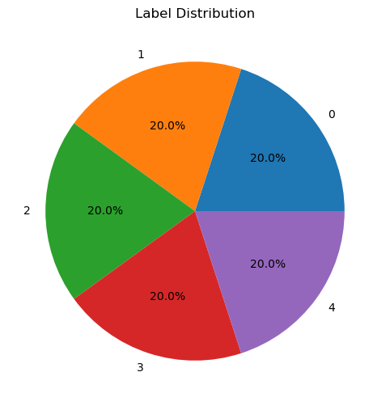

```python
# Count the occurrences of each label
label_counts = train_df['label'].value_counts().sort_index()

# Create a pie chart
plt.figure(figsize=(8, 6))
plt.pie(label_counts, labels=label_counts.index, autopct='%1.1f%%')
plt.title('Label Distribution')
plt.show()
```

## Keep only reviews of length equal to the middle 50%

Assume model will poorly predict sentiment on short reviews and also poorly predict sentiment on long reviews due to truncation

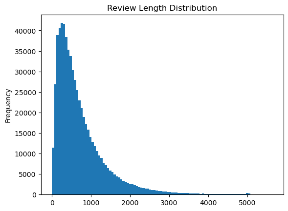

```
Data shape before filtering:  (650000, 3)
```

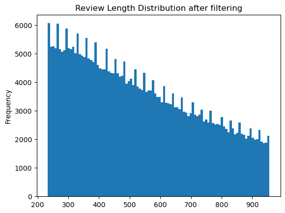

```
Data shape after filtering:  (365111, 3)
```

```python
train_df['review_length'] = train_df['text'].apply(len)
train_df['review_length'].plot(kind='hist', bins=100, title='Review Length Distribution')
plt.show()
print('Data shape before filtering: ',train_df.shape)

train_df = train_df[train_df['review_length'] < train_df['review_length'].quantile(0.75)]
train_df = train_df[train_df['review_length'] > train_df['review_length'].quantile(0.25)]
train_df['review_length'].plot(kind='hist', bins=100, title='Review Length Distribution after filtering')
plt.show()
print('Data shape after filtering: ',train_df.shape)
```

## Defining Sentiment Mapping

- How should we think about review labels and predicted sentiment?
- Obviously, if we only look at 0's and 4's, we expect our model to be more accurate
- What should we consider as neutral?
- What should we consider as positive and negative?
- This choices impact the assessment of the model

This allows us to assess with multiple perspectives

```python
# sentiment_mapping_one = {0: 'negative', 1: 'negative', 2: 'neutral', 3: 'positive', 4: 'positive'} #consider 0=1 negative, 3=4 positive, 2=neutral
# sentiment_mapping_two = {0: 'negative', 1: 'negative', 3: 'positive', 4: 'positive'}  #drop neutral
# sentiment_mapping_three = {0: 'negative', 4: 'positive'} #only look at extremes
# sentiment_mapping_four = {0: 'negative', 1 : 'neutral', 2 : 'neutral', 3: 'neutral', 4: 'positive'} #consider 0 negative, 4 positive, rest neutral

# sentiment_mappings = [sentiment_mapping_one, sentiment_mapping_two, sentiment_mapping_three, sentiment_mapping_four]
```

## Take subsample of dataset for testing purposes

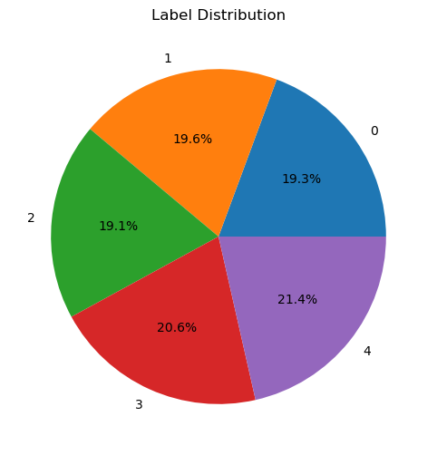

```python
if testing:
    train_df = train_df.sample(sample_size, random_state=42)

    # Count the occurrences of each label
    label_counts = train_df['label'].value_counts().sort_index()

    # Create a pie chart
    plt.figure(figsize=(8, 6))
    plt.pie(label_counts, labels=label_counts.index, autopct='%1.1f%%')
    plt.title('Label Distribution')
    plt.show()
```

## Part 2 - Sentiment Analysis

```python
reviews = train_df['text'].tolist()
all_model_results = [] #store all model results in this list
# sa_folder = 'sentiment_analysis/'
sent_pipes = []
models = []
```

## Model 1

https://huggingface.co/cardiffnlp/twitter-roberta-base-sentiment-latest

## Model 2

https://huggingface.co/distilbert/distilbert-base-uncased-finetuned-sst-2-english

This model doesn't have a neutral output

## Model 3

https://huggingface.co/siebert/sentiment-roberta-large-english

```python
model_one = 'cardiffnlp_twitter-roberta-base-sentiment'
models.append(model_one)
pipe = pipeline("text-classification", model="cardiffnlp/twitter-roberta-base-sentiment-latest", truncation=True, max_length=512)
sent_pipes.append(pipe)

model_two = 'distilbert-base-uncased-finetuned-sst-2-english'
models.append(model_two)
pipe = pipeline("text-classification", model="distilbert/distilbert-base-uncased-finetuned-sst-2-english", truncation=True, max_length=512) #when do i have to do this?
sent_pipes.append(pipe)

model_three = 'siebert_sentiment-roberta-large-english'
models.append(model_three)
pipe = pipeline("text-classification", model="siebert/sentiment-roberta-large-english", truncation=True, max_length=512)
sent_pipes.append(pipe)
```

[output not shown]

[output not shown]

```
|||||||||||||||||||||||||||||||||||||||||||||||||||||||||||||||||||||||||||||||||||||||||||||||


Running Sentiment Analysis for cardiffnlp_twitter-roberta-base-sentiment
```

```
	False Positives saved to file cardiffnlp_twitter-roberta-base-sentiment_worst_fp.csv in sentiment_analysis/
	21 0's predicted as positive. Top 10 worst predictions, sorted by probability:

Index 226334: I loved this place when I lived here and I always make sure to stop by and bring some friends here when I visit. The sushi was the BEST I have ever had until recently when I brought my 2 friends here for a belated Birthday dinner.\nThe presentation was always something to look forward …
Probability: 0.9670135974884033
-----------------
Index 441767: I'll keep this as short as possible.\n\nEveryone I know has told me how great this place is.\n\nSo I walk in yesterday with my friends at 5:10pm. First visit ever. \n\nAs soon as we get to the counter, one of the sandwich guys loudly says \"Hey guys, we close at 6, so make it quick. We…
Probability: 0.9347745776176453
-----------------
Index 401350: Super cute little place, so much so that I took a pic and sent it to my fiance. I went fo lunch on a Saturday while on my lunchbreak. I was quickly seated as there was only one other group there. Ordered and ice tea to find they only have the raspberry nestea. Was pleasantly surprised …
Probability: 0.9126245975494385
-----------------
Index 295366: I am at Roka writing this review. Upon entering this restaurant, we were impressed by the decor, music, and door handles. We were on time (even a little early) and notified that they could seat us after a 30 minute wait. We took their offer to sit outside (February) with only a 5 minut…
Probability: 0.8987172842025757
-----------------
Index 425025: I love all italian food.. From pasta to pizza to anything with cheese, pepperoni & sauce. & generally speaking, I'm not terribly picky when it comes to food. Last night, my boyfriend and I got a to-go calzone, their 5 cheese calzone, to be exact. The bread was over cooked, none of the …
Probability: 0.8674928545951843
-----------------
Index 65940: I simply can't wait to go back to Vegas to visit this place.....er, wait, that is another review.\n\nOn the contrary, being an early morning kinda guy and not wanting to disturb my roommate I decided to go for a morning run and ended up going to this 7-Eleven around 5:45am.  The coffee …
Probability: 0.864753246307373
-----------------
Index 260929: The first time we went here was in September. It was such a great time we thought we would try it again. This time it was completely different. We came at night and waited about 10 minutes for a table inside. So a table opened and we sat down. I got my cigar out and was getting ready t…
Probability: 0.8579598665237427
-----------------
Index 280014: This Hotel looks great from the highway, and the grounds are beautiful; great place to take pictures! Most of the Staff seemed very nice... But from the Lobby you will smell cigarette smoke, the rooms are in dyer need of upgrade, generally this needs major upgrading throughout! It's a …
Probability: 0.8322454690933228
-----------------
Index 561054: I am a huge fan of quaint hole-in-the-wall caf\u00e9s and am a connoisseur of coffee so when this new place opened up I thought it looked pretty promising.  I was completely misled, however, as this was probably one if the worst customer experiences I have had to date. I couldn't belie…
Probability: 0.8104665279388428
-----------------
Index 66588: This is a review of the male dance review\nA girlfriend and I went to this club on a Sunday night. The strippers were mostly amatuers and they all danced like girls. We called Palomino and they picked us up from OG and we ended up having a great night!! But you know different strokes fo…
Probability: 0.7783764600753784
-----------------
	False Negatives saved to file cardiffnlp_twitter-roberta-base-sentiment_worst_fn.csv in sentiment_analysis/
	15 4's predicted as negative. Top 10 worst predictions, sorted by probability:

Index 157284: If you're from Pittsburgh, you already know.\n\nIf you aren't, I shouldn't torture you.\n\nIf you're there and you don't know, then you aren't from Pittsburgh.  You need to go.  You need to go right now.  Don't even finish reading this review.  Go right now.\n\nYou should be reading th…
Probability: 0.761990487575531
-----------------
Index 309820: Man, I so miss this burger chain living on the east coast.\n\nI've only eaten at one In-N-Out Burger place that was slightly sub-par, and this wasn't it.  Service like at a Chik-fil-a: We were about to sit down and a guy came running over to wipe down the table and seats.  They actuall…
```

[output cut: 17 more lines]

```
Index 377933: I really don't enjoy buffets. But if you go with friends to Vegas, you really have to give in and go for the experience. I had already been disappointed by the ones at Bellagio and Wynn. One more wouldn't hurt. \n\nThis is a really great buffet! The experience was really pleasant and q…
Probability: 0.595540463924408
-----------------
Index 590938: HNS was not the first place I called. The other places were way over priced and would charge me $50 just to look at it (oh but they'd waive that if I overpaid and had them fix my door) or we're unavailable until this evening. So glad I called HNS. Gave me a quote over the phone, got a …
Probability: 0.5629318356513977
-----------------
Index 526536: Came in after a long day with a long night ahead of me. They were closing in 15 minutes, so half-expected some glares and huffs & puffs from young staff. However, this was certainly NOT my experience. I was greeted warmly and service was quick. The same was for the guy who came in 5 mi…
Probability: 0.5548994541168213
-----------------

Average length of false positives: 615.19
Average length of false negatives: 683.33
Average length of reviews: 529.47
Mapping from original data to prediction labels: [(0, 'negative'), (1, 'negative'), (2, 'neutral'), (3, 'positive'), (4, 'positive')]
Number of predictions: 2000
```

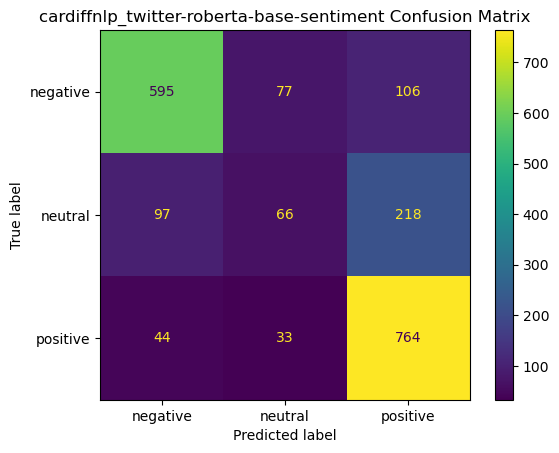

```
              precision    recall  f1-score   support

    negative       0.81      0.76      0.79       778
     neutral       0.38      0.17      0.24       381
    positive       0.70      0.91      0.79       841

    accuracy                           0.71      2000
   macro avg       0.63      0.62      0.61      2000
weighted avg       0.68      0.71      0.68      2000

Mapping from original data to prediction labels: [(0, 'negative'), (1, 'negative'), (3, 'positive'), (4, 'positive')]
Number of predictions: 1619
```

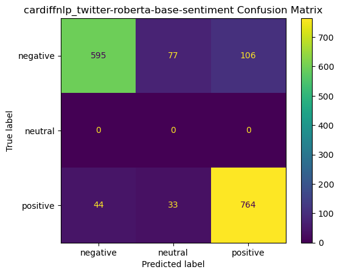

```
              precision    recall  f1-score   support

    negative       0.93      0.76      0.84       778
     neutral       0.00      0.00      0.00         0
    positive       0.88      0.91      0.89       841

    accuracy                           0.84      1619
   macro avg       0.60      0.56      0.58      1619
weighted avg       0.90      0.84      0.87      1619

Mapping from original data to prediction labels: [(0, 'negative'), (4, 'positive')]
Number of predictions: 816
```

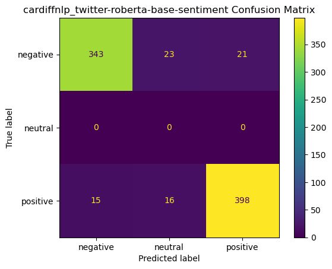

```
              precision    recall  f1-score   support

    negative       0.96      0.89      0.92       387
     neutral       0.00      0.00      0.00         0
    positive       0.95      0.93      0.94       429

    accuracy                           0.91       816
   macro avg       0.64      0.60      0.62       816
weighted avg       0.95      0.91      0.93       816

Mapping from original data to prediction labels: [(0, 'negative'), (1, 'neutral'), (2, 'neutral'), (3, 'neutral'), (4, 'positive')]
Number of predictions: 2000
```

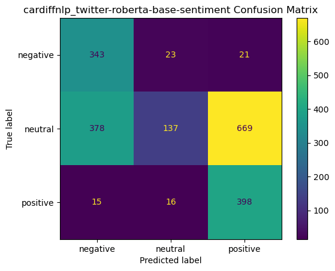

```
              precision    recall  f1-score   support

    negative       0.47      0.89      0.61       387
     neutral       0.78      0.12      0.20      1184
    positive       0.37      0.93      0.52       429

    accuracy                           0.44      2000
   macro avg       0.54      0.64      0.45      2000
weighted avg       0.63      0.44      0.35      2000

|||||||||||||||||||||||||||||||||||||||||||||||||||||||||||||||||||||||||||||||||||||||||||||||


|||||||||||||||||||||||||||||||||||||||||||||||||||||||||||||||||||||||||||||||||||||||||||||||


Running Sentiment Analysis for distilbert-base-uncased-finetuned-sst-2-english
	False Positives saved to file distilbert-base-uncased-finetuned-sst-2-english_worst_fp.csv in sentiment_analysis/
	18 0's predicted as positive. Top 10 worst predictions, sorted by probability:

Index 66588: This is a review of the male dance review\nA girlfriend and I went to this club on a Sunday night. The strippers were mostly amatuers and they all danced like girls. We called Palomino and they picked us up from OG and we ended up having a great night!! But you know different strokes fo…
Probability: 0.9985981583595276
-----------------
Index 146665: Nothing but Mama Luke's here.  The kind of place you frequent and take of employees and get no respect. Don't waste your time here. Unless you call ahead and make sure Ralph is not working. Then, there is actually a bartender who takes care of you and is a decent guy. The food is good …
Probability: 0.9985166192054749
-----------------
Index 458796: Went to Galaxie Electronics, and they found nothing wrong with the mechanics of my tape duplicator, other than the fact that they needed some oil. What were really affecting the quality were a few bad capacitors. The tapes sound nice and consistent now. There are two places in this cit…
Probability: 0.996626615524292
-----------------
Index 70420: This was the second time I have visited Road Runner, the first was about 5 years ago.  My husband and I decided to give it another chance, as it was very late and we were hungry.  The menu was pretty small and there was only one bartender late night to serve us...And I still looked past…
Probability: 0.9955398440361023
-----------------
Index 641830: Well, if I came here only to watch the game I would have given this place 5 stars based on the atmosphere.  However, came here for lunch and 20 minutes later I still have no drink. Oh, and six waitresses have walked past me but not said a word. What great customer service! Kudos to you…
Probability: 0.9916191101074219
-----------------
Index 176063: Pure is not the worst place I have been to in Vegas, but surely not the best.  I wouldn't go back, unless someone paid me.  The music was the only thing that saved this club.  This past Saturday night we went to Pure.  We found a spot to chill by the bar.  It took about 45 minutes to g…
Probability: 0.9861134886741638
-----------------
Index 523141: This is a place for local rednecks! I didn't think I'd find em in this neighborhood, but they are there. The bartender was slow and only paid attention to her regulars. The food was OK, and the beer was not cold enough. There was a very awkward moment when the regulars were howling abo…
Probability: 0.9794669151306152
```

[output cut: 34 more lines]

```
Index 58802: Winning!!\n\n$1 margaritas all day, every day?!?! For real?!?!  Yes!!! And $2 tequila shots!!\n\nCame here with the local hottie and we spent $6 for two margaritas and two additional tequila shots.  With $1 margaritas, I was expecting something along the lines of a lime slushie.  I was …
Probability: 0.9944773316383362
-----------------
Index 309820: Man, I so miss this burger chain living on the east coast.\n\nI've only eaten at one In-N-Out Burger place that was slightly sub-par, and this wasn't it.  Service like at a Chik-fil-a: We were about to sit down and a guy came running over to wipe down the table and seats.  They actuall…
Probability: 0.9935560822486877
-----------------
Index 565478: At the Las Vegas Foodie Festival I waited 3 hours for White Castle, an hour for White Rabbit and another hour for a sushi burrito... And they all didn't compare to The Big Easy Balls from Sauced! The best part was I only had to wait about 15 minutes! I was mad at myself for waiting so …
Probability: 0.9912242889404297
-----------------

Average length of false positives: 486.67
Average length of false negatives: 569.39
Average length of reviews: 529.47
Mapping from original data to prediction labels: [(0, 'negative'), (1, 'negative'), (2, 'neutral'), (3, 'positive'), (4, 'positive')]
Number of predictions: 2000
```

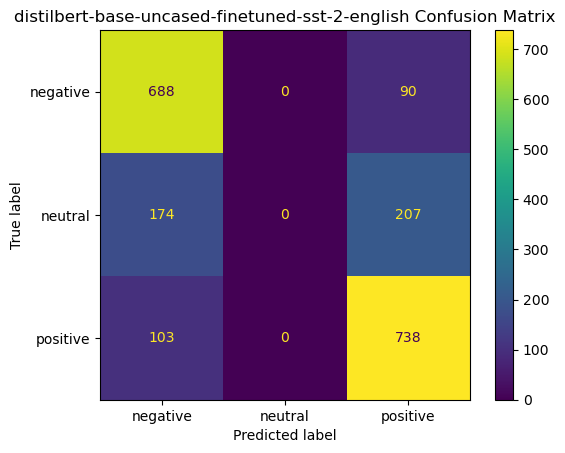

```
              precision    recall  f1-score   support

    negative       0.71      0.88      0.79       778
     neutral       0.00      0.00      0.00       381
    positive       0.71      0.88      0.79       841

    accuracy                           0.71      2000
   macro avg       0.48      0.59      0.53      2000
weighted avg       0.58      0.71      0.64      2000

Mapping from original data to prediction labels: [(0, 'negative'), (1, 'negative'), (3, 'positive'), (4, 'positive')]
Number of predictions: 1619
```

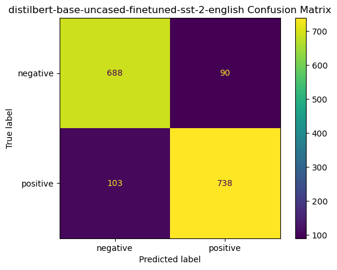

```
              precision    recall  f1-score   support

    negative       0.87      0.88      0.88       778
    positive       0.89      0.88      0.88       841

    accuracy                           0.88      1619
   macro avg       0.88      0.88      0.88      1619
weighted avg       0.88      0.88      0.88      1619

Mapping from original data to prediction labels: [(0, 'negative'), (4, 'positive')]
Number of predictions: 816
```

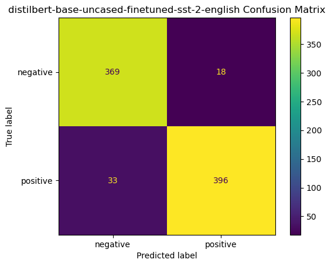

```
              precision    recall  f1-score   support

    negative       0.92      0.95      0.94       387
    positive       0.96      0.92      0.94       429

    accuracy                           0.94       816
   macro avg       0.94      0.94      0.94       816
weighted avg       0.94      0.94      0.94       816

Mapping from original data to prediction labels: [(0, 'negative'), (1, 'neutral'), (2, 'neutral'), (3, 'neutral'), (4, 'positive')]
Number of predictions: 2000
```

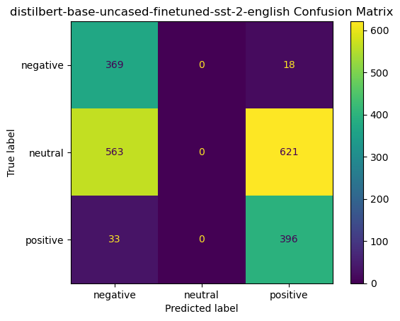

```
              precision    recall  f1-score   support

    negative       0.38      0.95      0.55       387
     neutral       0.00      0.00      0.00      1184
    positive       0.38      0.92      0.54       429

    accuracy                           0.38      2000
   macro avg       0.25      0.63      0.36      2000
weighted avg       0.16      0.38      0.22      2000

|||||||||||||||||||||||||||||||||||||||||||||||||||||||||||||||||||||||||||||||||||||||||||||||


|||||||||||||||||||||||||||||||||||||||||||||||||||||||||||||||||||||||||||||||||||||||||||||||


Running Sentiment Analysis for siebert_sentiment-roberta-large-english
	False Positives saved to file siebert_sentiment-roberta-large-english_worst_fp.csv in sentiment_analysis/
	4 0's predicted as positive. Top 10 worst predictions, sorted by probability:

Index 458796: Went to Galaxie Electronics, and they found nothing wrong with the mechanics of my tape duplicator, other than the fact that they needed some oil. What were really affecting the quality were a few bad capacitors. The tapes sound nice and consistent now. There are two places in this cit…
Probability: 0.998771607875824
-----------------
Index 333895: Ok, c'est l'alternative facile \u00e0 l'Avenue quand la line up est infinie. Mais \u00e7a n'en vaut vraiment pas la peine. J'ai choisi les oeufs b\u00e9n\u00e9dictines et c'\u00e9tait franchement pas bon. Accueil assez froid alors que la salle \u00e9tait d\u00e9serte. On passe son chem…
Probability: 0.9962694644927979
-----------------
Index 295366: I am at Roka writing this review. Upon entering this restaurant, we were impressed by the decor, music, and door handles. We were on time (even a little early) and notified that they could seat us after a 30 minute wait. We took their offer to sit outside (February) with only a 5 minut…
Probability: 0.9927912950515747
-----------------
Index 38978: Customer service rep who came to the vehicle made it seem like he had something better to do. Informed him that I called ahead to a UHaul down the road, asking if I could drop the truck off at this location instead. I was told this would not be a problem. The customer service rep told m…
Probability: 0.9832035303115845
-----------------
	False Negatives saved to file siebert_sentiment-roberta-large-english_worst_fn.csv in sentiment_analysis/
	5 4's predicted as negative. Top 10 worst predictions, sorted by probability:

Index 565478: At the Las Vegas Foodie Festival I waited 3 hours for White Castle, an hour for White Rabbit and another hour for a sushi burrito... And they all didn't compare to The Big Easy Balls from Sauced! The best part was I only had to wait about 15 minutes! I was mad at myself for waiting so …
Probability: 0.9994804263114929
-----------------
Index 11773: If you're into smoked meat, you've found you're home in the CU. The brisket is as good as it gets. Most of the sides are good to. The scalloped potatoes are awesome. Maybe it'd be better in Texas, but I think they'd even say this was pretty good.\nI really miss it now that I'm in Califo…
Probability: 0.9978876709938049
-----------------
Index 309820: Man, I so miss this burger chain living on the east coast.\n\nI've only eaten at one In-N-Out Burger place that was slightly sub-par, and this wasn't it.  Service like at a Chik-fil-a: We were about to sit down and a guy came running over to wipe down the table and seats.  They actuall…
Probability: 0.9965192079544067
-----------------
Index 324287: go see this zoo.  it's not the best zoo around, ok maybe it's the worst zoo around, BUT, it has some interesting animals and they clearly need your entrance fee to support their non-profit-ness.   Use the coupon on their web page to get a few bucks off. (it's not that much to get in to…
Probability: 0.9895716905593872
-----------------
Index 157284: If you're from Pittsburgh, you already know.\n\nIf you aren't, I shouldn't torture you.\n\nIf you're there and you don't know, then you aren't from Pittsburgh.  You need to go.  You need to go right now.  Don't even finish reading this review.  Go right now.\n\nYou should be reading th…
Probability: 0.9770522117614746
-----------------

Average length of false positives: 463.50
Average length of false negatives: 504.00
Average length of reviews: 529.47
Mapping from original data to prediction labels: [(0, 'negative'), (1, 'negative'), (2, 'neutral'), (3, 'positive'), (4, 'positive')]
Number of predictions: 2000
```

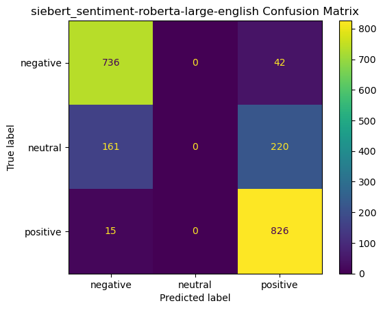

```
              precision    recall  f1-score   support

    negative       0.81      0.95      0.87       778
     neutral       0.00      0.00      0.00       381
    positive       0.76      0.98      0.86       841

    accuracy                           0.78      2000
   macro avg       0.52      0.64      0.58      2000
weighted avg       0.63      0.78      0.70      2000

Mapping from original data to prediction labels: [(0, 'negative'), (1, 'negative'), (3, 'positive'), (4, 'positive')]
Number of predictions: 1619
```

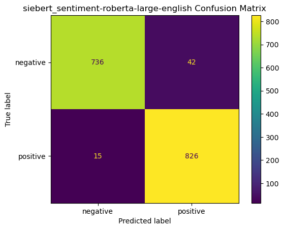

```
              precision    recall  f1-score   support

    negative       0.98      0.95      0.96       778
    positive       0.95      0.98      0.97       841

    accuracy                           0.96      1619
   macro avg       0.97      0.96      0.96      1619
weighted avg       0.97      0.96      0.96      1619

Mapping from original data to prediction labels: [(0, 'negative'), (4, 'positive')]
Number of predictions: 816
```

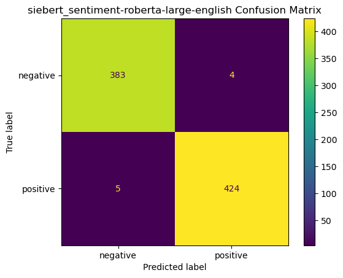

```
              precision    recall  f1-score   support

    negative       0.99      0.99      0.99       387
    positive       0.99      0.99      0.99       429

    accuracy                           0.99       816
   macro avg       0.99      0.99      0.99       816
weighted avg       0.99      0.99      0.99       816

Mapping from original data to prediction labels: [(0, 'negative'), (1, 'neutral'), (2, 'neutral'), (3, 'neutral'), (4, 'positive')]
Number of predictions: 2000
```

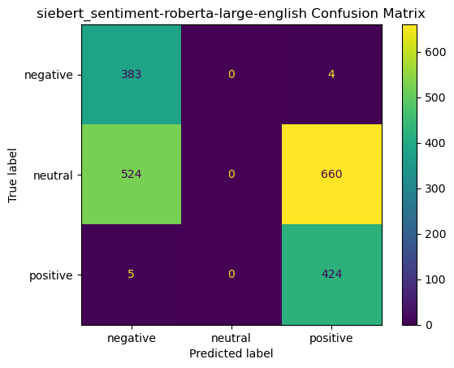

```
              precision    recall  f1-score   support

    negative       0.42      0.99      0.59       387
     neutral       0.00      0.00      0.00      1184
    positive       0.39      0.99      0.56       429

    accuracy                           0.40      2000
   macro avg       0.27      0.66      0.38      2000
weighted avg       0.16      0.40      0.23      2000

|||||||||||||||||||||||||||||||||||||||||||||||||||||||||||||||||||||||||||||||||||||||||||||||
```

```python
all_sent_model_acc_score = []

for model_name, pipe in zip(models, sent_pipes):
    print("|||||||||||||||||||||||||||||||||||||||||||||||||||||||||||||||||||||||||||||||||||||||||||||||\n\n")
    print(f'Running Sentiment Analysis for {model_name}')
    sent_analyzed_train_df = create_sent_analysis_or_load(train_df, model_name, pipe, reviews)
    train_df[model_name + '_pred_label'] = sent_analyzed_train_df['pred_label']

    report_worst_predictions(sent_analyzed_train_df, 'pred_label', 'label', 'pred_prob', model_name)

    model_acc_scores = conf_matrix_all_sent_maps_per_model(sent_analyzed_train_df, model_name, sentiment_mappings)
    all_sent_model_acc_score.append(model_acc_scores)
    print("|||||||||||||||||||||||||||||||||||||||||||||||||||||||||||||||||||||||||||||||||||||||||||||||\n\n")
```

## Compare Models

```python
pprint(all_sent_model_acc_score)
```

```
[{'mapping_0_accuracy': 0.7125,
  'mapping_1_accuracy': 0.8394,
  'mapping_2_accuracy': 0.9081,
  'mapping_3_accuracy': 0.439,
  'model_name': 'cardiffnlp_twitter-roberta-base-sentiment'},
 {'mapping_0_accuracy': 0.713,
  'mapping_1_accuracy': 0.8808,
  'mapping_2_accuracy': 0.9375,
  'mapping_3_accuracy': 0.3825,
  'model_name': 'distilbert-base-uncased-finetuned-sst-2-english'},
 {'mapping_0_accuracy': 0.781,
  'mapping_1_accuracy': 0.9648,
  'mapping_2_accuracy': 0.989,
  'mapping_3_accuracy': 0.4035,
  'model_name': 'siebert_sentiment-roberta-large-english'}]
```

```python
mapping_dict = {}
y = sentiment_mappings.copy()
y.insert(0, 'sentiment label mapping')
for key, map in zip(all_sent_model_acc_score[0].keys(), y):
    mapping_dict[key] = map
all_sent_model_acc_score.append(mapping_dict)
acc_comparison = pd.DataFrame(all_sent_model_acc_score)
acc_comparison.to_csv(sa_folder+'sentiment_model_accuracy_comparison.csv')

acc_comparison
```

|  | model_name | mapping_0_accuracy | mapping_1_accuracy | mapping_2_accuracy | mapping_3_accuracy |
| --- | --- | --- | --- | --- | --- |
| 0 | cardiffnlp_twitter-roberta-base-sentiment | 0.7125 | 0.8394 | 0.9081 | 0.439 |
| 1 | distilbert-base-uncased-finetuned-sst-2-english | 0.713 | 0.8808 | 0.9375 | 0.3825 |
| 2 | siebert_sentiment-roberta-large-english | 0.781 | 0.9648 | 0.989 | 0.4035 |
| 3 | sentiment label mapping | {0: 'negative', 1: 'negative', 2: 'neutral', 3... | {0: 'negative', 1: 'negative', 3: 'positive', ... | {0: 'negative', 4: 'positive'} | {0: 'negative', 1: 'neutral', 2: 'neutral', 3:... |

## model 3, Sibert/sentiment-roberta-large-english is the clear winner across all mappings except for the last, but that mapping is not a good one to judge by

```python
train_df
```

|  | label | text | review_length | cardiffnlp_twitter-roberta-base-sentiment_pred_label | distilbert-base-uncased-finetuned-sst-2-english_pred_label | siebert_sentiment-roberta-large-english_pred_label |
| --- | --- | --- | --- | --- | --- | --- |
| 352956 | 4 | This place is brilliant. For a night out defi... | 668 | positive | positive | positive |
| 34248 | 2 | Ok I'll admit they have reasonable prices on s... | 482 | positive | negative | positive |
| 555818 | 2 | I've wanted to come to Crudo for awhile so I w... | 567 | positive | positive | positive |
| 403173 | 1 | Good flavorful food but personally I didn't li... | 474 | negative | negative | negative |
| 263526 | 0 | If I could give this place no stars I would!!!... | 631 | negative | negative | negative |
| ... | ... | ... | ... | ... | ... | ... |
| 274443 | 2 | I always go to Harkins to watch movies. This t... | 670 | positive | positive | positive |
| 494550 | 4 | Best Club in Las Vegas for sure!!!\n\nMy frien... | 612 | positive | positive | positive |
| 398260 | 3 | After years of searching and having to settle ... | 953 | positive | positive | positive |
| 609043 | 4 | Paul's Pelmeni does one thing and one thing on... | 923 | positive | positive | positive |
| 293007 | 0 | Although the room is beautiful and comfortable... | 551 | negative | negative | negative |

2000 rows × 6 columns

```python
models = [model_one, model_two, model_three]

model_compare = train_df[['text', 'label']]

for model in models:
    model_df = pd.read_csv(sa_folder+model + "_sent_analysis.csv", index_col = 0)
    model_compare[model + '_pred_label'] = model_df['pred_label'].str.lower()

model_compare.to_csv(sa_folder+'model_comparison.csv')

model_compare
```

|  | text | label | cardiffnlp_twitter-roberta-base-sentiment_pred_label | distilbert-base-uncased-finetuned-sst-2-english_pred_label | siebert_sentiment-roberta-large-english_pred_label |
| --- | --- | --- | --- | --- | --- |
| 352956 | This place is brilliant. For a night out defi... | 4 | positive | positive | positive |
| 34248 | Ok I'll admit they have reasonable prices on s... | 2 | positive | negative | positive |
| 555818 | I've wanted to come to Crudo for awhile so I w... | 2 | positive | positive | positive |
| 403173 | Good flavorful food but personally I didn't li... | 1 | negative | negative | negative |
| 263526 | If I could give this place no stars I would!!!... | 0 | negative | negative | negative |
| ... | ... | ... | ... | ... | ... |
| 274443 | I always go to Harkins to watch movies. This t... | 2 | positive | positive | positive |
| 494550 | Best Club in Las Vegas for sure!!!\n\nMy frien... | 4 | positive | positive | positive |
| 398260 | After years of searching and having to settle ... | 3 | positive | positive | positive |
| 609043 | Paul's Pelmeni does one thing and one thing on... | 4 | positive | positive | positive |
| 293007 | Although the room is beautiful and comfortable... | 0 | negative | negative | negative |

2000 rows × 5 columns

## Find disagreements

```python
disagreements = model_compare[model_compare[[model + '_pred_label' for model in models]].nunique(axis=1) > 1]
disagreements.to_csv(sa_folder+'sentiment_model_disagreements.csv')
```

```python
disagreements
```

|  | text | label | cardiffnlp_twitter-roberta-base-sentiment_pred_label | distilbert-base-uncased-finetuned-sst-2-english_pred_label | siebert_sentiment-roberta-large-english_pred_label |
| --- | --- | --- | --- | --- | --- |
| 34248 | Ok I'll admit they have reasonable prices on s... | 2 | positive | negative | positive |
| 326802 | I've only been here a couple of times with som... | 3 | positive | negative | positive |
| 602950 | If you would like to spend $30 on a glorified ... | 0 | positive | positive | negative |
| 13871 | I came here after a grueling evening swim prac... | 1 | positive | negative | negative |
| 264667 | Here is what I can tell you about The Mix, it ... | 1 | positive | negative | negative |
| ... | ... | ... | ... | ... | ... |
| 453765 | If you own a printer then you'll know just how... | 3 | negative | negative | positive |
| 546583 | My wife and I went in tonight, as we had plann... | 4 | neutral | positive | positive |
| 490848 | Went there with a friend for lunch and it was ... | 2 | neutral | negative | negative |
| 561363 | Was on time. Seemed knowledgeable. Gave some... | 0 | neutral | negative | negative |
| 329939 | This place is probably more for kids. \nI only... | 2 | positive | positive | negative |

545 rows × 5 columns

### Look at distribution of disagreements

```python
disagreements['label'].value_counts()
```

```
label
2    194
1    155
3     93
0     53
4     50
Name: count, dtype: int64
```

```python
incorrect_negatives = disagreements[disagreements['label'] == 0]
max_negatives = incorrect_negatives.shape[0]
report_num = min(10, max_negatives)
for i in range(report_num):
    print(f"Review: {incorrect_negatives.iloc[i]['text']}")
    print(f"True label: {incorrect_negatives.iloc[i]['label']}")
    for model in models:
        print(f"{model} prediction: {incorrect_negatives.iloc[i][model + '_pred_label']}")
    print('-----------------')
    print('-----------------')
```

```
Review: If you would like to spend $30 on a glorified entree that is the size of a decent appetizer, this is the place for you! If you like to wait 12 minutes for a glass of water when there are only 5 tables filled in the restaurant, this is the place for you! If you like food with no seasoning and…
True label: 0
cardiffnlp_twitter-roberta-base-sentiment prediction: positive
distilbert-base-uncased-finetuned-sst-2-english prediction: positive
siebert_sentiment-roberta-large-english prediction: negative
-----------------
-----------------
Review: I will preface this by saying that I do understand that Burger King is considered fast food, but I was heading through the LV airport on the way home and decided to grab a quick breakfast sandwich.  I was promptly greeted and placed my order for a muffin breakfast sandwich with just egg and …
True label: 0
cardiffnlp_twitter-roberta-base-sentiment prediction: neutral
distilbert-base-uncased-finetuned-sst-2-english prediction: negative
siebert_sentiment-roberta-large-english prediction: negative
-----------------
-----------------
Review: I needed three appliances repaired so I thought I could save some money if I got them done by one company.  So I made an appointment for the next day from 2:00 pm to 4:00 pm.  The next morning they called to change the appointment to 11:00 am to 2:00 pm, OK I'll switch m am business to pm.  …
True label: 0
cardiffnlp_twitter-roberta-base-sentiment prediction: neutral
distilbert-base-uncased-finetuned-sst-2-english prediction: negative
siebert_sentiment-roberta-large-english prediction: negative
-----------------
-----------------
Review: I went here today after all the rave reviews and comments from my friends. First impressions: to start out, it's located in a business center. There is only a very little sign on the side walk with their name. With the interesting choice of location, comes with a very small, cramped and conf…
True label: 0
cardiffnlp_twitter-roberta-base-sentiment prediction: neutral
distilbert-base-uncased-finetuned-sst-2-english prediction: negative
siebert_sentiment-roberta-large-english prediction: negative
-----------------
-----------------
Review: This is a review of the male dance review\nA girlfriend and I went to this club on a Sunday night. The strippers were mostly amatuers and they all danced like girls. We called Palomino and they picked us up from OG and we ended up having a great night!! But you know different strokes for dif…
True label: 0
cardiffnlp_twitter-roberta-base-sentiment prediction: positive
distilbert-base-uncased-finetuned-sst-2-english prediction: positive
siebert_sentiment-roberta-large-english prediction: negative
-----------------
-----------------
Review: We have eaten here a few times. The food is ok, it's healthy. The workers are friendly.  The place is clean, ok. \n\nThe prices are high for the sizes. There aren't many ingredients on most dishes, they are simple so I feel the price is a bit high for what you get. \n\nMy 1 start is because …
True label: 0
cardiffnlp_twitter-roberta-base-sentiment prediction: positive
distilbert-base-uncased-finetuned-sst-2-english prediction: negative
siebert_sentiment-roberta-large-english prediction: negative
```

[output cut: 15 more lines]

```
-----------------
Review: Went there Valentine Day\n\nHad seen good reviews\n\nOnly a few available tables on open-table at 545p\n\nNot even 4 tables occupied out of 50 when we got there 5:30p\n\nPaleya poor: have had way better\n\nSignature cocktail $20 poor\n\nOnly good: Desert Flann
True label: 0
cardiffnlp_twitter-roberta-base-sentiment prediction: neutral
distilbert-base-uncased-finetuned-sst-2-english prediction: negative
siebert_sentiment-roberta-large-english prediction: negative
-----------------
-----------------
Review: This was the second time I have visited Road Runner, the first was about 5 years ago.  My husband and I decided to give it another chance, as it was very late and we were hungry.  The menu was pretty small and there was only one bartender late night to serve us...And I still looked past it a…
True label: 0
cardiffnlp_twitter-roberta-base-sentiment prediction: neutral
distilbert-base-uncased-finetuned-sst-2-english prediction: positive
siebert_sentiment-roberta-large-english prediction: negative
-----------------
-----------------
```

```python
incorrect_positives = disagreements[disagreements['label'] == 4]
max_positives = incorrect_positives.shape[0]
report_num = min(10, max_positives)
for i in range(report_num):
    print(f"Review: {incorrect_positives.iloc[i]['text']}")
    print(f"True label: {incorrect_positives.iloc[i]['label']}")
    for model in models:
        print(f"{model} prediction: {incorrect_positives.iloc[i][model + '_pred_label']}")
    print('-----------------')
    print('-----------------')
```

```
Review: Similaire \u00e0 mon amour pour le Vieux-Port, ce coin de la ville repr\u00e9sente pour moi un vestige de l'\u00e8re industrielle, de l'industrie du textile d'antan et des premiers brasseurs d'ici! Bref, un canal o\u00f9 on part \u00e0 la rencontre, en kayak, \u00e0 v\u00e9lo, \u00e0 pied ou…
True label: 4
cardiffnlp_twitter-roberta-base-sentiment prediction: neutral
distilbert-base-uncased-finetuned-sst-2-english prediction: negative
siebert_sentiment-roberta-large-english prediction: positive
-----------------
-----------------
Review: go see this zoo.  it's not the best zoo around, ok maybe it's the worst zoo around, BUT, it has some interesting animals and they clearly need your entrance fee to support their non-profit-ness.   Use the coupon on their web page to get a few bucks off. (it's not that much to get in to begin…
True label: 4
cardiffnlp_twitter-roberta-base-sentiment prediction: positive
distilbert-base-uncased-finetuned-sst-2-english prediction: negative
siebert_sentiment-roberta-large-english prediction: negative
-----------------
-----------------
Review: Peu m'importe que le march\u00e9 soit loin de chez moi : je l'aime tellement que \u00e7a vaut bien de faire un petit tour en m\u00e9tro pour y arriver ! \n\nGros coup de coeur pour ce grand march\u00e9, ouvert l'\u00e9t\u00e9, couvert l'hiver aux multiples surprises : des fruits et l\u00e9gu…
True label: 4
cardiffnlp_twitter-roberta-base-sentiment prediction: neutral
distilbert-base-uncased-finetuned-sst-2-english prediction: negative
siebert_sentiment-roberta-large-english prediction: positive
-----------------
-----------------
Review: Call me premenstrual or just sensitive, but today incurred the first mediocre experience at The Garage. Since today has already earned it's trophy \"case of the mondays\" cliche, I spent most of the afternoon (from 12:01 onwards!) wishing I was here enjoying my post-work Stella w my sis. It …
True label: 4
cardiffnlp_twitter-roberta-base-sentiment prediction: negative
distilbert-base-uncased-finetuned-sst-2-english prediction: negative
siebert_sentiment-roberta-large-english prediction: positive
-----------------
-----------------
Review: First time reviewer of anything, but I do consult these kind of sites when wanting to try something new. As a regular at Veritas, when I came across some of these bad reviews, I decided to finally write a post for all the Veritas regulars out there. I take a detour at least 3-4 times a week …
True label: 4
cardiffnlp_twitter-roberta-base-sentiment prediction: neutral
distilbert-base-uncased-finetuned-sst-2-english prediction: positive
siebert_sentiment-roberta-large-english prediction: positive
-----------------
-----------------
Review: We had an annoying check engine light for the past 6 months on a 2009 Jeep Grand Cherokee Limited.  We have had bad experiences in the past with the dealers and decided to try a local repair shop.  How fortunate we were to stumble onto Ken's Auto Repair Service on the internet!!!  Ken is ver…
True label: 4
cardiffnlp_twitter-roberta-base-sentiment prediction: negative
distilbert-base-uncased-finetuned-sst-2-english prediction: positive
siebert_sentiment-roberta-large-english prediction: positive
```

[output cut: 15 more lines]

```
-----------------
Review: 99% Adorable\n1% Creepy for the crazy mannequin that's usually dressed up outside by the road\n\nAnd I never fail to walk out with something 98% of the time I'm there. I've bought everything from amazing glass pie plates to a vegetable steamer to little utensils. It's unbelievable how many d…
True label: 4
cardiffnlp_twitter-roberta-base-sentiment prediction: positive
distilbert-base-uncased-finetuned-sst-2-english prediction: negative
siebert_sentiment-roberta-large-english prediction: positive
-----------------
-----------------
Review: what?! twice in one week?! um.. yes. Stopped by while they were at SK&G Advertising by 215 and Russell. It was a bit tough to find thanks to Google Maps with the roads labeled wrong.\n\nI caught them at the tale end of their 3 hr stay and there were a few ppl around still. I got 2 porkies, 2…
True label: 4
cardiffnlp_twitter-roberta-base-sentiment prediction: neutral
distilbert-base-uncased-finetuned-sst-2-english prediction: negative
siebert_sentiment-roberta-large-english prediction: positive
-----------------
-----------------
```

```python
worst_predictions = pd.concat([incorrect_negatives, incorrect_positives])
worst_predictions['sentiment'] = worst_predictions['label'].map(sentiment_mapping_three)
worst_predictions

model_failures = {}
for model in models:
    worst_predictions[model+'_failure'] = worst_predictions[model + '_pred_label'] != worst_predictions['sentiment']
    model_failures[model] = worst_predictions[model+'_failure'].sum()

worst_predictions
```

|  | text | label | cardiffnlp_twitter-roberta-base-sentiment_pred_label | distilbert-base-uncased-finetuned-sst-2-english_pred_label | siebert_sentiment-roberta-large-english_pred_label | sentiment | cardiffnlp_twitter-roberta-base-sentiment_failure | distilbert-base-uncased-finetuned-sst-2-english_failure | siebert_sentiment-roberta-large-english_failure |
| --- | --- | --- | --- | --- | --- | --- | --- | --- | --- |
| 602950 | If you would like to spend $30 on a glorified ... | 0 | positive | positive | negative | negative | True | True | False |
| 571745 | I will preface this by saying that I do unders... | 0 | neutral | negative | negative | negative | True | False | False |
| 485502 | I needed three appliances repaired so I though... | 0 | neutral | negative | negative | negative | True | False | False |
| 605286 | I went here today after all the rave reviews a... | 0 | neutral | negative | negative | negative | True | False | False |
| 66588 | This is a review of the male dance review\nA g... | 0 | positive | positive | negative | negative | True | True | False |
| ... | ... | ... | ... | ... | ... | ... | ... | ... | ... |
| 318938 | LOVE THE BRUNCH!!! We went here with a group f... | 4 | positive | negative | positive | positive | False | True | False |
| 366099 | I found the place on my phone after seeing a f... | 4 | positive | negative | positive | positive | False | True | False |
| 128325 | I loooove Fat Tuesdays! \n\nProbably the only ... | 4 | positive | negative | positive | positive | False | True | False |
| 510930 | I was looking for a fresh perspective for my l... | 4 | neutral | positive | positive | positive | True | False | False |
| 546583 | My wife and I went in tonight, as we had plann... | 4 | neutral | positive | positive | positive | True | False | False |

103 rows × 9 columns

```python
pd.Series(model_failures)
```

```
cardiffnlp_twitter-roberta-base-sentiment          72
distilbert-base-uncased-finetuned-sst-2-english    48
siebert_sentiment-roberta-large-english             6
dtype: int64
```

Siebert is a winner

# Part 3 - Zero Shot Classification

```python
train_df
```

|  | label | text | review_length | cardiffnlp_twitter-roberta-base-sentiment_pred_label | distilbert-base-uncased-finetuned-sst-2-english_pred_label | siebert_sentiment-roberta-large-english_pred_label |
| --- | --- | --- | --- | --- | --- | --- |
| 352956 | 4 | This place is brilliant. For a night out defi... | 668 | positive | positive | positive |
| 34248 | 2 | Ok I'll admit they have reasonable prices on s... | 482 | positive | negative | positive |
| 555818 | 2 | I've wanted to come to Crudo for awhile so I w... | 567 | positive | positive | positive |
| 403173 | 1 | Good flavorful food but personally I didn't li... | 474 | negative | negative | negative |
| 263526 | 0 | If I could give this place no stars I would!!!... | 631 | negative | negative | negative |
| ... | ... | ... | ... | ... | ... | ... |
| 274443 | 2 | I always go to Harkins to watch movies. This t... | 670 | positive | positive | positive |
| 494550 | 4 | Best Club in Las Vegas for sure!!!\n\nMy frien... | 612 | positive | positive | positive |
| 398260 | 3 | After years of searching and having to settle ... | 953 | positive | positive | positive |
| 609043 | 4 | Paul's Pelmeni does one thing and one thing on... | 923 | positive | positive | positive |
| 293007 | 0 | Although the room is beautiful and comfortable... | 551 | negative | negative | negative |

2000 rows × 6 columns

## Summarization

Reviews are already pretty short. The average number of tokens in a review (filtered to include middle 50% by char length from step 1) is on the order of 130. The model we use defaults to summmarizations with a maximum length of 147.

Set summarization model max_length to about half the number of tokens found in the minumum review. Set min_length to something like 10 tokens.

What should we do?

## We're trying to summarize reviews, which are already pretty short.

```python
model = 'facebook/bart-large-cnn'
sum_folder = 'summary_sentiment_analysis/'
```

```python
tokenizer = AutoTokenizer.from_pretrained("facebook/bart-large-cnn")
```

```python
review_token_length = []
for review in reviews:
    tokenized_review = tokenizer(review)
    review_token_length.append(len(tokenized_review['input_ids']))
```

```python
np.mean(review_token_length)
```

```
128.415
```

```python
np.min(review_token_length)
```

```
49
```

```python
summarizer = pipeline("summarization", model=model, max_length=25, min_length=10)
```

```python
summarizer(reviews[5])[0]
```

```
{'summary_text': 'The food is excellent - the soups are amazing (especially the Garden Chili and Tomato Basil Feta soup)'}
```

```python
if not os.path.exists(sum_folder):
    os.makedirs(sum_folder)
if not os.path.exists(sum_folder+'summarized_reviews.csv'):
    summaries = [summarizer(review)[0]['summary_text'] for review in reviews]
    train_df['summary'] = summaries
    train_df.to_csv(sum_folder+'summarized_reviews.csv')
else:
    train_df = pd.read_csv(sum_folder+'summarized_reviews.csv', index_col=0)
    summaries = train_df['summary']
```

```python
train_df
```

|  | label | text | review_length | cardiffnlp_twitter-roberta-base-sentiment_pred_label | distilbert-base-uncased-finetuned-sst-2-english_pred_label | siebert_sentiment-roberta-large-english_pred_label | summary |
| --- | --- | --- | --- | --- | --- | --- | --- |
| 352956 | 4 | This place is brilliant. For a night out defi... | 668 | positive | positive | positive | This place is brilliant. For a night out defin... |
| 34248 | 2 | Ok I'll admit they have reasonable prices on s... | 482 | positive | negative | positive | This is a fine place to go shooting as long as... |
| 555818 | 2 | I've wanted to come to Crudo for awhile so I w... | 567 | positive | positive | positive | The wait staff was professional and efficient.... |
| 403173 | 1 | Good flavorful food but personally I didn't li... | 474 | negative | negative | negative | Good flavorful food but personally I didn't li... |
| 263526 | 0 | If I could give this place no stars I would!!!... | 631 | negative | negative | negative | The manager didn't even check in his stock and... |
| ... | ... | ... | ... | ... | ... | ... | ... |
| 274443 | 2 | I always go to Harkins to watch movies. This t... | 670 | positive | positive | positive | I always go to Harkins to watch movies. This t... |
| 494550 | 4 | Best Club in Las Vegas for sure!!!\n\nMy frien... | 612 | positive | positive | positive | The dance floor was great, music even better. ... |
| 398260 | 3 | After years of searching and having to settle ... | 953 | positive | positive | positive | Fries are great as well. Nothing fancy and it ... |
| 609043 | 4 | Paul's Pelmeni does one thing and one thing on... | 923 | positive | positive | positive | The beef dumplings have a good chew, while the... |
| 293007 | 0 | Although the room is beautiful and comfortable... | 551 | negative | negative | negative | The air quality is awful. I stayed 6 nights fo... |

2000 rows × 7 columns

# Part 3a

```
|||||||||||||||||||||||||||||||||||||||||||||||||||||||||||||||||||||||||||||||||||||||||||||||||||||||||||||||||||||||||||||||
Running sentiment analysis for cardiffnlp_twitter-roberta-base-sentiment
	False Positives saved to file cardiffnlp_twitter-roberta-base-sentiment_worst_fp.csv in summary_sentiment_analysis/
	45 0's predicted as positive. Top 10 worst predictions, sorted by probability:

Index 401350: Super cute little place, so much so that I took a pic and sent it to my fiance. I went fo lunch on a Saturday while on my lunchbreak. I was quickly seated as there was only one other group there. Ordered and ice tea to find they only have the raspberry nestea. Was pleasantly surprised …
Probability: 0.9860364198684692
-----------------
Index 280014: This Hotel looks great from the highway, and the grounds are beautiful; great place to take pictures! Most of the Staff seemed very nice... But from the Lobby you will smell cigarette smoke, the rooms are in dyer need of upgrade, generally this needs major upgrading throughout! It's a …
Probability: 0.9857289791107178
-----------------
Index 636557: 1 star ...not for the coffee. I love the coffee and the new Chai tea is awesome. I hate this specific location...I've been here every Tuesday and Wednesday for the past 4 months and every single time I dread, horrifically dread coming here because I've literally sat 10 minutes in my ca…
Probability: 0.9800864458084106
-----------------
Index 596457: Was really looking forward to a burlesque type show.   The music was good and the dancers were entertaining.   Clair St Claire was less then entertaining.  She is the \"star\" of the show and seems very awkward on stage the whole time.   I felt a little bad for her because it really se…
Probability: 0.9797817468643188
-----------------
Index 260929: The first time we went here was in September. It was such a great time we thought we would try it again. This time it was completely different. We came at night and waited about 10 minutes for a table inside. So a table opened and we sat down. I got my cigar out and was getting ready t…
Probability: 0.9776903986930847
-----------------
Index 369398: Great decoration, the gold fishes in the huge tanks in the entry are really cool. The cool playing with his noodles is great animation. \nBUT when it comes to the food, it's not the same story maybe it was too \"Chinese food\" for us. \nHubby took roasted duck, but there was not much m…
Probability: 0.9764658212661743
-----------------
Index 55683: we quit going to chilis about a year ago because the food was so-so..we thought we would give it another try.well,nothing has changed. We started with guacamole dip as an appetizer, it was quite tasty however the chips and salsa were so salty you could not eat them..i had the Cajun chic…
Probability: 0.9638343453407288
-----------------
Index 138115: The person answering the phone was great, friendly , knew her stuff! I placed the order which  was around $30. I informed her that I was paying in cash and with a 100 dollar bill. At this point I was placed on hold and then instructed that unless I was paying by card my order was not h…
Probability: 0.9592698812484741
-----------------
Index 59135: My Doctor was dr  John Brown he was a wonderful dr. He cared about you he was theperson that held the clinic together now he is gone and I dont have a doctor. I called in aprescription and had to wait 4 days before i received it. machelle the nurse or office gril said i would have it an…
Probability: 0.9589419960975647
-----------------
Index 292021: Being ignored for 10 minutes in Las Vegas when you are two girls at a bar is highly unlikely. But the older, heavier bartender at the heart bar is doing a great job in just that - topping it off with a 'seen-it-all'- I've had enough - jaded attitude that's not the charming kind but the…
Probability: 0.9469379782676697
-----------------
	False Negatives saved to file cardiffnlp_twitter-roberta-base-sentiment_worst_fn.csv in summary_sentiment_analysis/
	16 4's predicted as negative. Top 10 worst predictions, sorted by probability:

Index 283995: I should have ran, (not walked), in the other direction when I saw the word \"Bread\". Chocolate chip cookies are a weakness of mine, and, oh - what's this? Pumpkin Chocolate Chip Bread? With butter? That is a recipe for self-destruction! Everything in moderation, right? Nope. It seems…
Probability: 0.9254847764968872
```

[output cut: 19 more lines]

```
Index 251128: I'm not a huge fan of pizza, but man the thin crust is to die for.  The garlic on top of the pizza is delish!  Had the 'white pizza with garlic sauce' last week and this week tried the tomato based sauce.  Both were very good.  I'm definately going to be a regular at Grimaldi's.
Probability: 0.7171850204467773
-----------------
Index 441040: Ok....I tend to blow up my computers....(multiple monitor crazy setup) which I did....and these guys had the patience to do EVERYTHING it took to get me back in business.  Thanks guys....besides they are good people and easy to deal with!
Probability: 0.7168405055999756
-----------------
Index 100540: I love this place! \n\nI have white blond eyebrows and eyelashes, and finding a salon that can dye them the correct colors without making a mess of things is difficult at best.  When I explained exactly what I needed the girl who did my tinting (sadly I can't remember her name, but she…
Probability: 0.7042616009712219
-----------------

Average length of false positives: 95.38
Average length of false negatives: 96.25
Average length of reviews: 96.17
Mapping from original data to prediction labels: [(0, 'negative'), (1, 'negative'), (2, 'neutral'), (3, 'positive'), (4, 'positive')]
Number of predictions: 2000
```

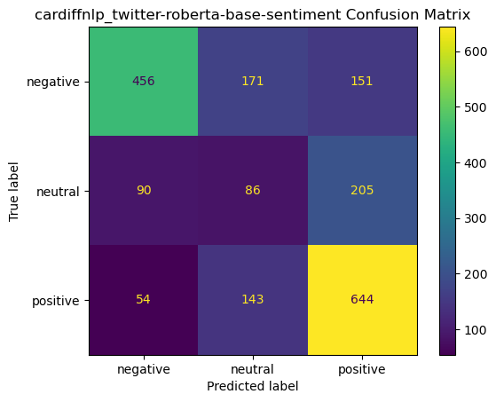

```
              precision    recall  f1-score   support

    negative       0.76      0.59      0.66       778
     neutral       0.21      0.23      0.22       381
    positive       0.64      0.77      0.70       841

    accuracy                           0.59      2000
   macro avg       0.54      0.53      0.53      2000
weighted avg       0.61      0.59      0.59      2000

Mapping from original data to prediction labels: [(0, 'negative'), (1, 'negative'), (3, 'positive'), (4, 'positive')]
Number of predictions: 1619
```

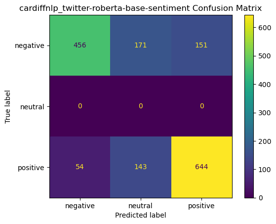

```
              precision    recall  f1-score   support

    negative       0.89      0.59      0.71       778
     neutral       0.00      0.00      0.00         0
    positive       0.81      0.77      0.79       841

    accuracy                           0.68      1619
   macro avg       0.57      0.45      0.50      1619
weighted avg       0.85      0.68      0.75      1619

Mapping from original data to prediction labels: [(0, 'negative'), (4, 'positive')]
Number of predictions: 816
```

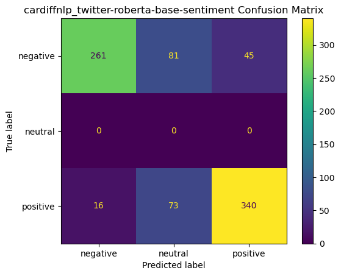

```
              precision    recall  f1-score   support

    negative       0.94      0.67      0.79       387
     neutral       0.00      0.00      0.00         0
    positive       0.88      0.79      0.84       429

    accuracy                           0.74       816
   macro avg       0.61      0.49      0.54       816
weighted avg       0.91      0.74      0.81       816

Mapping from original data to prediction labels: [(0, 'negative'), (1, 'neutral'), (2, 'neutral'), (3, 'neutral'), (4, 'positive')]
Number of predictions: 2000
```

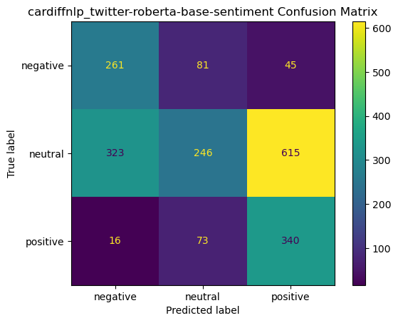

```
              precision    recall  f1-score   support

    negative       0.43      0.67      0.53       387
     neutral       0.61      0.21      0.31      1184
    positive       0.34      0.79      0.48       429

    accuracy                           0.42      2000
   macro avg       0.46      0.56      0.44      2000
weighted avg       0.52      0.42      0.39      2000

|||||||||||||||||||||||||||||||||||||||||||||||||||||||||||||||||||||||||||||||||||||||||||||||||||||||||||||||||||||||||||||||
|||||||||||||||||||||||||||||||||||||||||||||||||||||||||||||||||||||||||||||||||||||||||||||||||||||||||||||||||||||||||||||||
Running sentiment analysis for distilbert-base-uncased-finetuned-sst-2-english
	False Positives saved to file distilbert-base-uncased-finetuned-sst-2-english_worst_fp.csv in summary_sentiment_analysis/
	57 0's predicted as positive. Top 10 worst predictions, sorted by probability:

Index 280014: This Hotel looks great from the highway, and the grounds are beautiful; great place to take pictures! Most of the Staff seemed very nice... But from the Lobby you will smell cigarette smoke, the rooms are in dyer need of upgrade, generally this needs major upgrading throughout! It's a …
Probability: 0.9998828172683716
-----------------
Index 596457: Was really looking forward to a burlesque type show.   The music was good and the dancers were entertaining.   Clair St Claire was less then entertaining.  She is the \"star\" of the show and seems very awkward on stage the whole time.   I felt a little bad for her because it really se…
Probability: 0.9998705387115479
-----------------
Index 636557: 1 star ...not for the coffee. I love the coffee and the new Chai tea is awesome. I hate this specific location...I've been here every Tuesday and Wednesday for the past 4 months and every single time I dread, horrifically dread coming here because I've literally sat 10 minutes in my ca…
Probability: 0.999847412109375
-----------------
Index 549080: We have eaten here a few times. The food is ok, it's healthy. The workers are friendly.  The place is clean, ok. \n\nThe prices are high for the sizes. There aren't many ingredients on most dishes, they are simple so I feel the price is a bit high for what you get. \n\nMy 1 start is be…
Probability: 0.9998302459716797
-----------------
Index 407195: I visited a few days ago and I had high expectations. I ordered some common Korean fare and it smelled good. However there were so many fruit flies everywhere and they crawled over everything; there were hundreds of them. I finished my soup and boxed up everything and went home. I can'…
Probability: 0.9997842907905579
-----------------
Index 59135: My Doctor was dr  John Brown he was a wonderful dr. He cared about you he was theperson that held the clinic together now he is gone and I dont have a doctor. I called in aprescription and had to wait 4 days before i received it. machelle the nurse or office gril said i would have it an…
Probability: 0.9997610449790955
-----------------
Index 555551: Cannot stand this store. It's much worth your walk to head south on Vegas blvd. and hit cvs or the other Walgreens a block down. Constantly having issues with security being overzealous and immature with tyrannical agendas.  No thanks! I'll pay exuberant prices for convenience on the s…
Probability: 0.999739944934845
-----------------
Index 223102: My relatives are visiting from China and wanted to try some American food. I took them to the las vegas strip Outback. The food was pretty good and it appeared that for Las Vegas, the service was good as well. The total food bill was 82 and we tipped 12 (about 15%). Later when we check…
Probability: 0.9997150301933289
-----------------
```

[output cut: 30 more lines]

```
Index 107508: The CD player in my car was not working and I took it in, expecting to pay many hundreds of dollars. The technician took it in the back, spent a few minutes looking, and said there was nothing the matter with it. It absolutely had not been working when I took it in, but it has been wor…
Probability: 0.9988290667533875
-----------------
Index 510930: I was looking for a fresh perspective for my lame hair.  Been going to the same hairdresser for the 7 years that I lived here, and had an appointment to go back, then saw the HomeRun deal for LIndsey.  I thought hmmmm.....maybe I should try something different.  Lindsey took the time t…
Probability: 0.9987726807594299
-----------------
Index 204577: I'm going to marry the Gobi Manchurian. kids will follow. This food is so good it would throw my principles to the ground, but it's all vegetarian and most of the menu is vegan. thank you Udupi for your wonderful oily menu. yeah, it's not super healthy, but amazing anyway.
Probability: 0.9986282587051392
-----------------

Average length of false positives: 95.09
Average length of false negatives: 91.16
Average length of reviews: 96.17
Mapping from original data to prediction labels: [(0, 'negative'), (1, 'negative'), (2, 'neutral'), (3, 'positive'), (4, 'positive')]
Number of predictions: 2000
```

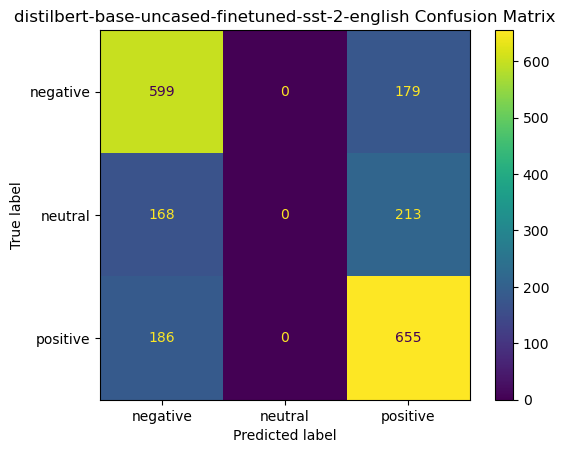

```
              precision    recall  f1-score   support

    negative       0.63      0.77      0.69       778
     neutral       0.00      0.00      0.00       381
    positive       0.63      0.78      0.69       841

    accuracy                           0.63      2000
   macro avg       0.42      0.52      0.46      2000
weighted avg       0.51      0.63      0.56      2000

Mapping from original data to prediction labels: [(0, 'negative'), (1, 'negative'), (3, 'positive'), (4, 'positive')]
Number of predictions: 1619
```

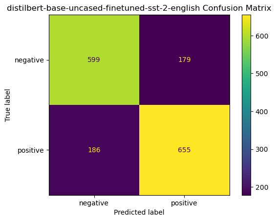

```
              precision    recall  f1-score   support

    negative       0.76      0.77      0.77       778
    positive       0.79      0.78      0.78       841

    accuracy                           0.77      1619
   macro avg       0.77      0.77      0.77      1619
weighted avg       0.77      0.77      0.77      1619

Mapping from original data to prediction labels: [(0, 'negative'), (4, 'positive')]
Number of predictions: 816
```

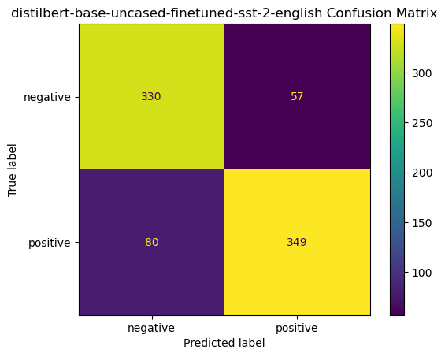

```
              precision    recall  f1-score   support

    negative       0.80      0.85      0.83       387
    positive       0.86      0.81      0.84       429

    accuracy                           0.83       816
   macro avg       0.83      0.83      0.83       816
weighted avg       0.83      0.83      0.83       816

Mapping from original data to prediction labels: [(0, 'negative'), (1, 'neutral'), (2, 'neutral'), (3, 'neutral'), (4, 'positive')]
Number of predictions: 2000
```

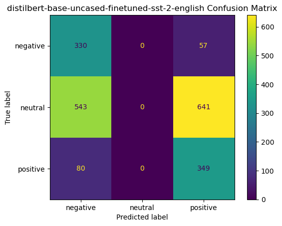

```
              precision    recall  f1-score   support

    negative       0.35      0.85      0.49       387
     neutral       0.00      0.00      0.00      1184
    positive       0.33      0.81      0.47       429

    accuracy                           0.34      2000
   macro avg       0.23      0.56      0.32      2000
weighted avg       0.14      0.34      0.20      2000

|||||||||||||||||||||||||||||||||||||||||||||||||||||||||||||||||||||||||||||||||||||||||||||||||||||||||||||||||||||||||||||||
|||||||||||||||||||||||||||||||||||||||||||||||||||||||||||||||||||||||||||||||||||||||||||||||||||||||||||||||||||||||||||||||
Running sentiment analysis for siebert_sentiment-roberta-large-english
	False Positives saved to file siebert_sentiment-roberta-large-english_worst_fp.csv in summary_sentiment_analysis/
	52 0's predicted as positive. Top 10 worst predictions, sorted by probability:

Index 280014: This Hotel looks great from the highway, and the grounds are beautiful; great place to take pictures! Most of the Staff seemed very nice... But from the Lobby you will smell cigarette smoke, the rooms are in dyer need of upgrade, generally this needs major upgrading throughout! It's a …
Probability: 0.998900294303894
-----------------
Index 65940: I simply can't wait to go back to Vegas to visit this place.....er, wait, that is another review.\n\nOn the contrary, being an early morning kinda guy and not wanting to disturb my roommate I decided to go for a morning run and ended up going to this 7-Eleven around 5:45am.  The coffee …
Probability: 0.998871386051178
-----------------
Index 138115: The person answering the phone was great, friendly , knew her stuff! I placed the order which  was around $30. I informed her that I was paying in cash and with a 100 dollar bill. At this point I was placed on hold and then instructed that unless I was paying by card my order was not h…
Probability: 0.9988669157028198
-----------------
Index 260929: The first time we went here was in September. It was such a great time we thought we would try it again. This time it was completely different. We came at night and waited about 10 minutes for a table inside. So a table opened and we sat down. I got my cigar out and was getting ready t…
Probability: 0.9988538026809692
-----------------
Index 295366: I am at Roka writing this review. Upon entering this restaurant, we were impressed by the decor, music, and door handles. We were on time (even a little early) and notified that they could seat us after a 30 minute wait. We took their offer to sit outside (February) with only a 5 minut…
Probability: 0.9988530874252319
-----------------
Index 641830: Well, if I came here only to watch the game I would have given this place 5 stars based on the atmosphere.  However, came here for lunch and 20 minutes later I still have no drink. Oh, and six waitresses have walked past me but not said a word. What great customer service! Kudos to you…
Probability: 0.9988273978233337
-----------------
Index 292021: Being ignored for 10 minutes in Las Vegas when you are two girls at a bar is highly unlikely. But the older, heavier bartender at the heart bar is doing a great job in just that - topping it off with a 'seen-it-all'- I've had enough - jaded attitude that's not the charming kind but the…
Probability: 0.9988155364990234
-----------------
Index 499919: My sisters and I decided to do lunch here this past Sunday. It was freezing (for Az) outside and the windows were wide open. We sat at a table that still had not been cleaned yet, by the open window. 1. No one ever came over to clean up and we had to bus it ourselves 2. we got yelled a…
Probability: 0.9988082647323608
-----------------
```

[output cut: 30 more lines]

```
Index 107508: The CD player in my car was not working and I took it in, expecting to pay many hundreds of dollars. The technician took it in the back, spent a few minutes looking, and said there was nothing the matter with it. It absolutely had not been working when I took it in, but it has been wor…
Probability: 0.9988862872123718
-----------------
Index 593178: Believe the reviews!  I called early in the morning on a day scheduled to be 113 degrees, when everyone's air was going out. Not only did they get here earlier than they estimated, he determined the problem was the thermostat and not the ac, fixed it and the cost was minimal and he was…
Probability: 0.9987654685974121
-----------------
Index 441040: Ok....I tend to blow up my computers....(multiple monitor crazy setup) which I did....and these guys had the patience to do EVERYTHING it took to get me back in business.  Thanks guys....besides they are good people and easy to deal with!
Probability: 0.9983797073364258
-----------------

Average length of false positives: 96.17
Average length of false negatives: 92.96
Average length of reviews: 96.17
Mapping from original data to prediction labels: [(0, 'negative'), (1, 'negative'), (2, 'neutral'), (3, 'positive'), (4, 'positive')]
Number of predictions: 2000
```

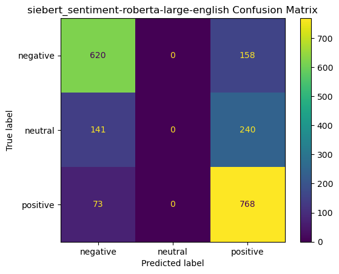

```
              precision    recall  f1-score   support

    negative       0.74      0.80      0.77       778
     neutral       0.00      0.00      0.00       381
    positive       0.66      0.91      0.77       841

    accuracy                           0.69      2000
   macro avg       0.47      0.57      0.51      2000
weighted avg       0.57      0.69      0.62      2000

Mapping from original data to prediction labels: [(0, 'negative'), (1, 'negative'), (3, 'positive'), (4, 'positive')]
Number of predictions: 1619
```

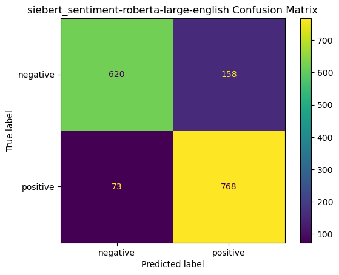

```
              precision    recall  f1-score   support

    negative       0.89      0.80      0.84       778
    positive       0.83      0.91      0.87       841

    accuracy                           0.86      1619
   macro avg       0.86      0.86      0.86      1619
weighted avg       0.86      0.86      0.86      1619

Mapping from original data to prediction labels: [(0, 'negative'), (4, 'positive')]
Number of predictions: 816
```

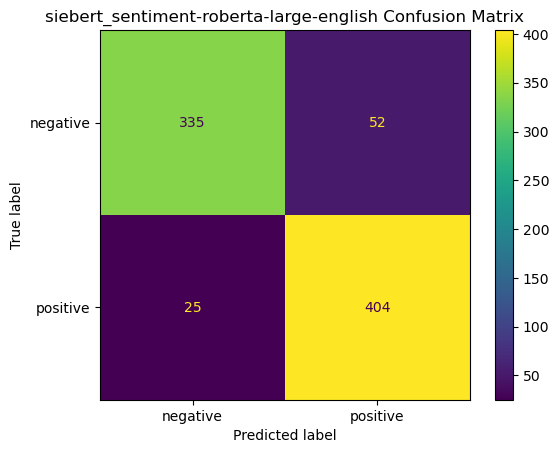

```
              precision    recall  f1-score   support

    negative       0.93      0.87      0.90       387
    positive       0.89      0.94      0.91       429

    accuracy                           0.91       816
   macro avg       0.91      0.90      0.90       816
weighted avg       0.91      0.91      0.91       816

Mapping from original data to prediction labels: [(0, 'negative'), (1, 'neutral'), (2, 'neutral'), (3, 'neutral'), (4, 'positive')]
Number of predictions: 2000
```

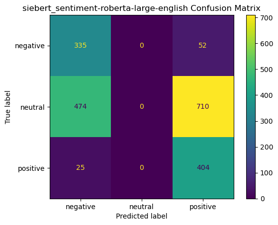

```
              precision    recall  f1-score   support

    negative       0.40      0.87      0.55       387
     neutral       0.00      0.00      0.00      1184
    positive       0.35      0.94      0.51       429

    accuracy                           0.37      2000
   macro avg       0.25      0.60      0.35      2000
weighted avg       0.15      0.37      0.21      2000

|||||||||||||||||||||||||||||||||||||||||||||||||||||||||||||||||||||||||||||||||||||||||||||||||||||||||||||||||||||||||||||||
```

```python
all_model_summary_results = []
for model, pipe in zip(models, sent_pipes):

    print('|||||||||||||||||||||||||||||||||||||||||||||||||||||||||||||||||||||||||||||||||||||||||||||||||||||||||||||||||||||||||||||||')
    print(f'Running sentiment analysis for {model}')
    train_df = create_sent_analysis_or_load(train_df, model, pipe, summaries, pred_col_name = model + '_sum_pred_label', sa_folder = sum_folder, pred_prob_col_name = model + '_sum_pred_prob')
    report_worst_predictions(train_df, model+'_sum_pred_label', 'label', model + '_sum_pred_prob', model, sa_folder = sum_folder, text = 'summary')
    model_assessment = conf_matrix_all_sent_maps_per_model(train_df, model, sentiment_mappings, pred_col_name = model + '_sum_pred_label', true_col_name = 'label')
    all_model_summary_results.append(model_assessment)
    print('|||||||||||||||||||||||||||||||||||||||||||||||||||||||||||||||||||||||||||||||||||||||||||||||||||||||||||||||||||||||||||||||')
```

```python
pprint(all_model_summary_results)

acc_comparison = pd.DataFrame(all_model_summary_results)
acc_comparison.to_csv(sum_folder+'sentiment_model_accuracy_comparison.csv')

acc_comparison
```

```
[{'mapping_0_accuracy': 0.593,
  'mapping_1_accuracy': 0.6794,
  'mapping_2_accuracy': 0.7365,
  'mapping_3_accuracy': 0.4235,
  'model_name': 'cardiffnlp_twitter-roberta-base-sentiment'},
 {'mapping_0_accuracy': 0.627,
  'mapping_1_accuracy': 0.7746,
  'mapping_2_accuracy': 0.8321,
  'mapping_3_accuracy': 0.3395,
  'model_name': 'distilbert-base-uncased-finetuned-sst-2-english'},
 {'mapping_0_accuracy': 0.694,
  'mapping_1_accuracy': 0.8573,
  'mapping_2_accuracy': 0.9056,
  'mapping_3_accuracy': 0.3695,
  'model_name': 'siebert_sentiment-roberta-large-english'}]
```

|  | model_name | mapping_0_accuracy | mapping_1_accuracy | mapping_2_accuracy | mapping_3_accuracy |
| --- | --- | --- | --- | --- | --- |
| 0 | cardiffnlp_twitter-roberta-base-sentiment | 0.593 | 0.6794 | 0.7365 | 0.4235 |
| 1 | distilbert-base-uncased-finetuned-sst-2-english | 0.627 | 0.7746 | 0.8321 | 0.3395 |
| 2 | siebert_sentiment-roberta-large-english | 0.694 | 0.8573 | 0.9056 | 0.3695 |

# Part 3b

```python
classes = ['Restaurant', 'Bar', 'Coffee', 'Hotel', 'Salon', 'Automotive', 'Home', 'Medical', 'Entertainment', 'Pet', 'Financial', 'Education', 'Real Estate', 'Fitness', 'Landscaping', 'Legal', 'Travel', 'Event', 'Retail', 'Beauty']
len(classes)
```

```
20
```

```python
model_one = 'facebook-bart-large-mnli'
pipe_one = pipeline("zero-shot-classification", model="facebook/bart-large-mnli")

pipe_one(reviews[0], classes)
```

```
{'sequence': "This place is brilliant.  For a night out definitely come here first.\\n\\nI tend to buy a couple of pitchers, highly recommend the fruit salad one and the Fab Ice Lolly one. Its just something totally different and a pitcher to 2 people is enough to get you a little tipsy. \\n\\nPrice…
 'labels': ['Entertainment',
  'Bar',
  'Restaurant',
  'Travel',
  'Financial',
  'Event',
  'Retail',
  'Home',
  'Beauty',
  'Hotel',
  'Education',
  'Real Estate',
  'Legal',
  'Salon',
  'Automotive',
  'Fitness',
  'Pet',
  'Medical',
  'Landscaping',
  'Coffee'],
 'scores': [0.25318923592567444,
  0.13311557471752167,
  0.08584100753068924,
  0.05718148127198219,
  0.05042918398976326,
  0.04934512823820114,
  0.04194752499461174,
  0.040127746760845184,
  0.03638220205903053,
  0.03399199992418289,
  0.02839033305644989,
  0.027142329141497612,
  0.026792874559760094,
  0.02675415761768818,
  0.02445317804813385,
  0.022878162562847137,
  0.022577278316020966,
  0.017548972740769386,
  0.015345245599746704,
  0.0065664127469062805]}
```

```python
model_two = 'MoritzLaurer-DeBERTa-v3-base-mnli-fever-anli'
pipe_two = pipeline("zero-shot-classification", model="MoritzLaurer/DeBERTa-v3-base-mnli-fever-anli")
pipe_two(reviews[0], classes)
```

```
Asking to truncate to max_length but no maximum length is provided and the model has no predefined maximum length. Default to no truncation.
```

```
{'sequence': "This place is brilliant.  For a night out definitely come here first.\\n\\nI tend to buy a couple of pitchers, highly recommend the fruit salad one and the Fab Ice Lolly one. Its just something totally different and a pitcher to 2 people is enough to get you a little tipsy. \\n\\nPrice…
 'labels': ['Entertainment',
  'Restaurant',
  'Retail',
  'Travel',
  'Financial',
  'Education',
  'Hotel',
  'Legal',
  'Event',
  'Bar',
  'Beauty',
  'Salon',
  'Automotive',
  'Home',
  'Pet',
  'Medical',
  'Real Estate',
  'Landscaping',
  'Fitness',
  'Coffee'],
 'scores': [0.2680423855781555,
  0.23645402491092682,
  0.19748704135417938,
  0.1124851405620575,
  0.04617432877421379,
  0.028915997594594955,
  0.025592796504497528,
  0.01916118711233139,
  0.01850697211921215,
  0.008646617643535137,
  0.007373587228357792,
  0.00641377829015255,
  0.00486982986330986,
  0.004396161530166864,
  0.0038976529613137245,
  0.0033102661836892366,
  0.0029140471015125513,
  0.0022225987631827593,
  0.0019932049326598644,
  0.0011423106770962477]}
```

```python
model_three = 'knowledgator-comprehend_it-base'
pipe_three = pipeline("zero-shot-classification", model="knowledgator/comprehend_it-base")
pipe_three(reviews[0], classes)
```

```
{'sequence': "This place is brilliant.  For a night out definitely come here first.\\n\\nI tend to buy a couple of pitchers, highly recommend the fruit salad one and the Fab Ice Lolly one. Its just something totally different and a pitcher to 2 people is enough to get you a little tipsy. \\n\\nPrice…
 'labels': ['Restaurant',
  'Entertainment',
  'Bar',
  'Retail',
  'Event',
  'Beauty',
  'Coffee',
  'Pet',
  'Travel',
  'Legal',
  'Home',
  'Financial',
  'Automotive',
  'Hotel',
  'Real Estate',
  'Fitness',
  'Medical',
  'Education',
  'Salon',
  'Landscaping'],
 'scores': [0.32537841796875,
  0.2530597150325775,
  0.14299000799655914,
  0.06996909528970718,
  0.037154942750930786,
  0.032331839203834534,
  0.025860149413347244,
  0.023575464263558388,
  0.011821764521300793,
  0.011131437495350838,
  0.00926794484257698,
  0.009058729745447636,
  0.00896851159632206,
  0.007526187691837549,
  0.0063428194262087345,
  0.0059715681709349155,
  0.005327884573489428,
  0.005245762411504984,
  0.005224882625043392,
  0.0037927827797830105]}
```

```python
models = [model_one, model_two, model_three]
pipes = [pipe_one, pipe_two, pipe_three]
```

```python
train_df
```

|  | label | text | cardiffnlp_twitter-roberta-base-sentiment_pred_label | distilbert-base-uncased-finetuned-sst-2-english_pred_label | siebert_sentiment-roberta-large-english_pred_label | summary | cardiffnlp_twitter-roberta-base-sentiment_sum_pred_label | cardiffnlp_twitter-roberta-base-sentiment_sum_pred_prob | distilbert-base-uncased-finetuned-sst-2-english_sum_pred_label | distilbert-base-uncased-finetuned-sst-2-english_sum_pred_prob | siebert_sentiment-roberta-large-english_sum_pred_label | siebert_sentiment-roberta-large-english_sum_pred_prob |
| --- | --- | --- | --- | --- | --- | --- | --- | --- | --- | --- | --- | --- |
| 352956 | 4 | This place is brilliant. For a night out defi... | positive | positive | positive | This place is brilliant. For a night out defin... | positive | 0.973247 | positive | 0.999820 | positive | 0.998928 |
| 34248 | 2 | Ok I'll admit they have reasonable prices on s... | positive | negative | positive | This is a fine place to go shooting as long as... | positive | 0.716102 | positive | 0.992242 | positive | 0.998682 |
| 555818 | 2 | I've wanted to come to Crudo for awhile so I w... | positive | positive | positive | The wait staff was professional and efficient.... | positive | 0.971938 | positive | 0.999709 | positive | 0.998903 |
| 403173 | 1 | Good flavorful food but personally I didn't li... | negative | negative | negative | Good flavorful food but personally I didn't li... | negative | 0.806084 | negative | 0.947319 | negative | 0.999325 |
| 263526 | 0 | If I could give this place no stars I would!!!... | negative | negative | negative | The manager didn't even check in his stock and... | negative | 0.700749 | negative | 0.998503 | negative | 0.999508 |
| ... | ... | ... | ... | ... | ... | ... | ... | ... | ... | ... | ... | ... |
| 274443 | 2 | I always go to Harkins to watch movies. This t... | positive | positive | positive | I always go to Harkins to watch movies. This t... | positive | 0.866439 | positive | 0.984276 | positive | 0.998883 |
| 494550 | 4 | Best Club in Las Vegas for sure!!!\n\nMy frien... | positive | positive | positive | The dance floor was great, music even better. ... | positive | 0.987264 | positive | 0.999530 | positive | 0.998849 |
| 398260 | 3 | After years of searching and having to settle ... | positive | positive | positive | Fries are great as well. Nothing fancy and it ... | positive | 0.942339 | positive | 0.999719 | positive | 0.998828 |
| 609043 | 4 | Paul's Pelmeni does one thing and one thing on... | positive | positive | positive | The beef dumplings have a good chew, while the... | positive | 0.947115 | positive | 0.999521 | positive | 0.998289 |
| 293007 | 0 | Although the room is beautiful and comfortable... | negative | negative | negative | The air quality is awful. I stayed 6 nights fo... | negative | 0.956692 | negative | 0.999775 | negative | 0.999494 |

2000 rows × 12 columns